[figure not shown]

Prof. Carlos Andrés Ferrero

# Mineração de Dados

## Pré-processamento: Medidas de qualidade de atributos

## Conteúdo

- Entropia
  - Entropia para problemas de duas classes
  - Entropia para problemas múltiplas classes
- Entropia de Atributos
- Medidas de Importância
  - Ganho de Informação (*Information Gain*)
  - Taxa de Ganho (*Gain Ratio*)

## Introduçao

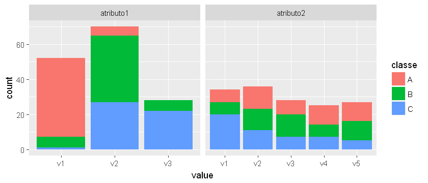

```r
plot1
```

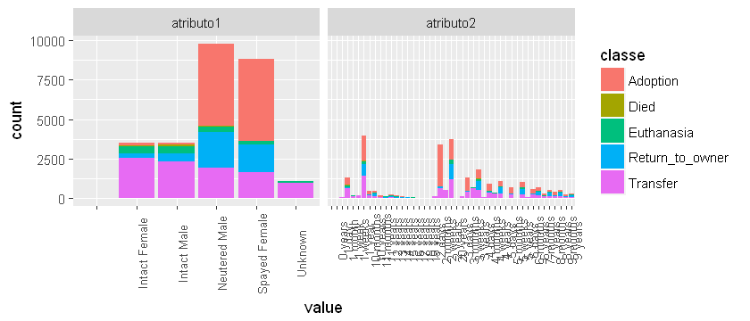

```r
plot2
```

## Entropia

- A *entropia* é uma medida de qualidade de atributos que mede a *desordem* de um conjunto de dados.
- Essa *desordem* diz respeito a quão bem organizados estão os dados em relação à classe.
- A medida é supervisionada, portanto para medir a *entropia* de um atributo precisamos ter um atributo classe.

### Cálculo de Entropia em um Problema de Duas Clases

- Considere um problema de duas clases em que uma delas é positiva (+) e a outra negativa (-). E um conjunto de dados $X$ que possui dados sobre esse problema.
- A função para medir a entropia é dada por:

$$ E(X) = -\;(\;\;p_+ \log_2{p_+}\;\;+\;\;p_- \times \log_2{p_-}\;\;) $$

- onde,
  - $p_+$ é a probabilidade de um exemplo ser da classe positiva
  - $p_-$ é a probabilidade de um exemplo ser da classe negativa

### Exemplos

- Vamos imaginar três possíveis conjuntos de dados para $X$
  1. $X_1$ só terá exemplos da classe positiva (+)
  2. $X_2$ só terá exemplos da classe negativa (-)
  3. $X_3$ terá metade dos exemplos da classe positiva e a outra metade da classe negativa
- Como $X_1$ só tem exemplos da classe positiva, então a probabilidade de um exemplo ser:
  - da classe positiva é simplesmente $p_+=1$
  - da classe negativa é $p_-=0$
- A entropia de $X_1$ é:

\begin{array}{lcl} E(X)&= & -\;(&p_+ \times \log_2{p_+} & + & p_- \times \log_2{p_-}&) \\ E(X_1)&= & -\;(&1 \times \log_2{1} & + & 0 \times \log_2{0}&) \\ E(X_1)&= & -\;(&1 \times 0 & + & 0 &) \\ E(X_1)&= & -\;(& 0 & + & 0 &) \\ E(X_1)&= & 0 \end{array}

- Uma *entropia* igual a *zero* significa que não há desordem neste conjunto de dados, devido a que todas os exemplos de $X_1$ são da mesma classe.
- O conjunto $X_2$ apenas tem exemplos da classe negativa, então a probabilidade de um exemplo ser:
  - da classe positiva é $p_+=0$
  - da classe negativa é $p_-=1$
- A entropia de $X_2$ é:

\begin{array}{llllll} E(X)&= & -\;(&p_+ \times \log_2{p_+} & + & p_- \times \log_2{p_-}&) \\ E(X_2)&= & -\;(&0 \times \log_2{0} & + & 1 \times \log_2{1}&) \\ E(X_2)&= & -\;(&0 & + & 1 \times 0&) \\ E(X_2)&= & -\;(& 0 & + & 0 &) \\ E(X_2)&= & 0 \end{array}

- Neste caso, a *desordem* também é zero devido a todos os elementos serem da classe negativa (-)
- Já no conjunto $X_3$ temos exemplos de ambas as classes, e a probabilidade de ser:
  - da classe positiva é $p_+=1/2$ ou $0.5$ ou $2^{-1}$
  - da classe negativa é $p_+=1/2$
- A entropia é:

\begin{array}{llllll} E(X)&= & -\;(&p_+ \times \log_2{p_+} & + & p_- \times \log_2{p_-}&) \\ E(X_3)&= & -\;(&0.5 \times \log_2{0.5} & + & 0.5 \times \log_2{0.5}&) \\ E(X_3)&= & -\;(&0.5 \times \log_2{2^{-1}} & + & 0.5 \times \log_2{2^{-1}}&) \\ E(X_3)&= & -\;(&-0.5 \times \log_2{2} & + & - 0.5 \times \log_2{2}&) \\ E(X_3)&= & -\;(&-0.5 \times 1 & + & - 0.5 \times 1&) \\ E(X_3)&= & -\;(&-0.5 & + & -0.5 &) \\ E(X_3)&= & -\;(& - 1 &&&) \\ E(X_3)&= & 1 \end{array}

- No conjunto $X_3$ a *entropia* ou desordem é 1 (máxima)
- Isso indica que em $X_3$ não é possível observar que alguma das classes prevalece nesse conjunto de dados.
- Agora, vamos considerar um conjunto de dados $X_4$ que possui $1/4$ de exemplos da classe positiva e $3/4$ de exemplos da classe negativa.
- Em uma problema de duas classes espera-se que o valor da entropia esteja entre 0 e 1.

\begin{array}{llllll} E(X)& = & -\;(&p_+ \times \log_2{p_+} & + & p_- \times \log_2{p_-}&) \\ E(X_4)&= & -\;(&1/4 \times \log_2{1/4} & + & 3/4 \times \log_2{3/4}&) \\ E(X_4)&= & -\;(&1/4 \times [\log_2{1} - \log_2{4}] & + & 3/4 \times [\log_2{3} - \log_2{4}]&) \\ E(X_4)&= & -\;(&1/4 \times [0 - 2] & + & 3/4 \times [1.58 - 2]&) \\ E(X_4)&= & -\;(&1/4 \times -2 & + & 3/4 \times -0.42&) \\ E(X_4)&= & -\;(&-0.5 & + & -0.32&) \\ E(X_4)&= & -\;(&-0.82 &&& ) \\ E(X_4)&= & 0.82 \\ \end{array}

### Uma função para cálculo de entropia para duas classes

- Nesta função podemos passar apenas a probabilidade da classe positiva e, com ela, calcular a probabilidade da negativa.
- Da forma como esta função foi implementada ela permite calcular a entropia de um valor de probabilidade ou de um vetor de valores de probabilidade.

```r
entropy.binary <- function(prob.positive){
    pa <- prob.positive
    pb <- 1 - prob.positive
    primeiro.termo <- ifelse(pa == 0, 0, pa * log2(pa))
    segundo.termo  <- ifelse(pb == 0, 0, pb * log2(pb))
    entropy <- (-1) * (primeiro.termo + segundo.termo)
    entropy
}
```

- Com essa função podemos calcular qual a entropia à medida que a probabilidade da classe positiva aumenta de 5% em 5%.

```r
library(data.table)
prob.positive <- seq(0,1,0.05) # Cria sequencia de 5% em 5%
entropy <- entropy.binary(prob.positive) # Calcula entropia
dt.entropy <- data.table(prob.positive, entropy)
head(dt.entropy)
```

| prob.positive | entropy |
| --- | --- |
| 0.00 | 0.0000000 |
| 0.05 | 0.2863970 |
| 0.10 | 0.4689956 |
| 0.15 | 0.6098403 |
| 0.20 | 0.7219281 |
| 0.25 | 0.8112781 |

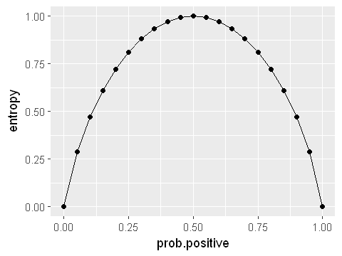

```r
library(ggplot2)
options(repr.plot.width=4, repr.plot.height=3)
ggplot(dt.entropy, aes(x=prob.positive, y=entropy)) + geom_line() + geom_point()
```

### Cálculo de Entropia para Problemas de Múltiplas Classes

- Muitos dos problemas que nos enfrentamos atualmente em mineração de dados possuem mais do que duas classes
- A Equação geral para cálculo de entropia de um conjunto de dados é:

$$ E(X) = - \sum_{i}^{c} p_i \times \log_2{p_i} $$

- onde,
  - $c$ é o número de classes do problema.
  - $p_i$ é a probabilidade de um exemplo ser da $i$-ésima classe.
- Note que para $c=2$ a equação é equivalente à de duas classes, definida anteriormente:

\begin{array}{llllll} E(X) & = & - \sum_{i=1}^{c=2} p_i \times \log_2{p_i} \\ E(X) & = & -\;(\;\;p_1 \times \log_2{p_1}\;+\;p_2 \times \log_2{p_2}\;\;) \end{array}

### Uma Função para Calcular a Entropia para Múltiplas Classes

- Como a entropia de um conjunto de dados depende apenas da coluna de dados do atributo classe, neste implementação usaremos apenas esse atributo para calcular a entropia.
- Assim, primeiro calculamos a frequência de elementos, usando a função *table* e dividimos pelo número de elementos do atributo classe para obter as probabilidades $P = (p_1, p_2, \dots, p_c)$ das classes.
- E após, com $P$ fazemos o calculo de entropia.

```r
entropia <- function(class.attribute){
    P <- table(class.attribute) / length(class.attribute)
    termos <- ifelse(P == 0, 0, P * log2(P))
    entropia <- (-1) * sum(termos)
    entropia
}
```

### Alguns Exemplos

#### Exemplo 1

- Dez exemplos com classes A, B e C.

```r
set.seed(1)
classe <- sample(c("A","B","C"),size=10,replace=T)
classe <- factor(classe, levels = c("A","B","C"))
print(classe)
```

```
 [1] A B B C A C C B B A
Levels: A B C
```

```r
entropia(classe)
```

1.57095059445467

#### Exemplo 2

- Dez exemplos com classes A, B e C ordenados.

```r
set.seed(1)
classe <- sort(sample(c("A","B","C"),size=10,replace=T))
classe <- factor(classe, levels = c("A","B","C"))
print(classe)
```

```
 [1] A A A B B B B C C C
Levels: A B C
```

```r
entropia(classe)
```

1.57095059445467

- Note que a ordem dos exemplos não altera o valor da entropia. Consideram-se os exemplos como eventos independentes.

#### Exemplo 3

- Dez exemplos do problema com três classes (A, B e C), mas apenas contendo exemplos com classes A e B.

```r
set.seed(1)
classe <- sample(c("A","B"),size=10,replace=T)
classe <- factor(classe, levels = c("A","B","C"))
print(classe)
```

```
 [1] A A B B A B B B B A
Levels: A B C
```

```r
entropia(classe)
```

0.970950594454669

- Ao diminuir o número de classes no conjunto (de três para duas) a entropia do conjunto diminuiu consideravelmente.

#### Exemplo 4

- Dez exemplos do problema com três classes (A, B e C), mas apenas contendo exemplos da classe A.

```r
set.seed(1)
classe <- sample(c("A"),size=10,replace=T)
classe <- factor(classe, levels = c("A","B","C"))
print(classe)
```

```
 [1] A A A A A A A A A A
Levels: A B C
```

```r
entropia(classe)
```

0

- Note como os valores de entropia descrescem à medida que o atributo classe vai ficando com elementos de apenas uma classe

#### Exemplo 5

- Dez exemplos de um problema com duas classes, A e B.

```r
set.seed(1)
classe <- sample(c("A","B"),size=10,replace=T)
classe <- factor(classe, levels = c("A","B"))
print(classe)
```

```
 [1] A A B B A B B B B A
Levels: A B
```

```r
entropia(classe)
```

0.970950594454669

- Esse resultado da entropia é o mesmo do *Exemplo 3*
- Observe que se o nosso problema é de 2 (A e B) classes ou de 3 classes (A, B e C), havendo elementos de duas classes (A e B), e a distribuição for a mesma, a entropia será igual.

## Entropia de Atributos

- Embora já conseguimos calcular a entropia de um conjunto de dados, baseado na sua classe, ainda precisamos calcular a *desordem* que cada atributo produz no conjunto de dados.
- Um atributo terá uma baixa entropia se os seus valores permitem dividir o conjunto de dados em partes com baixa entropia.
- Assim, para um atributo ter entropia 0 precisará que os valores do atributo dividam o conjunto de dados em partes com apenas uma classe.
- Por exemplo,

```r
dt <- data.table(atributo = rep(c("v1","v2","v3"),2),
                 classe   = rep(c("A","B","C"),2))[order(classe)]
dt
```

| atributo | classe |
| --- | --- |
| v1 | A |
| v1 | A |
| v2 | B |
| v2 | B |
| v3 | C |
| v3 | C |

- Observe o número de exemplos de cada classe para cada valor do atributo.

```r
table(dt$atributo,dt$classe)
```

```
     A B C
  v1 2 0 0
  v2 0 2 0
  v3 0 0 2
```

- Cada valor de atributo apresenta exemplos de apenas uma classe. Isso significa que os valores desse atributo permitem diferenciar bem as classes do problema.
- Para calcular a entropia de um atributo é necessário calcular a entropia de cada um dos conjuntos de dados gerados pelos seus valores e usar esse valor proporcionalmente ao tamanho de cada conjunto.
- Seja um atributo $A$ com possíveis valores $v_1, v_2, \ldots, v_m$, o calculo de Entropia do atributo $A$ é definido por:

$$ E(X,A) = \sum_{j=1}^{m} \frac{|X_{j}|}{|X|} \times E(X_{j}) $$

- onde,
  - $A$ é um atributo
  - $v$ é cada valor do atributo $A$, sem repetir
  - $X_{j}$ é a partição do conjunto $X$ em que o atributo $A$ possui valor $v_j$
  - $|X_{j}| / |X|$ é a proporção de valores $v_j$ no conjunto de dados
  - $E(X_j)$ é a entropia do conjunto $X_j$

### Exemplo

- Suponha o seguinte conjunto de dados, onde temos um atributo que pode assumir valores $v_1$, $v_2$ e $v_3$, e a classe (ou atributo classe) pode ser $A$, $B$ ou $C$.
- O conjunto de dados possui 50 elementos de cada classe, ao todo 150 elementos, então sua entropia inicial é:

```r
entropia(dt$classe)
```

1.58496250072116

- O seguinte gráfico nos mostra a frequência das classes para os diferentes valores do *atributo*

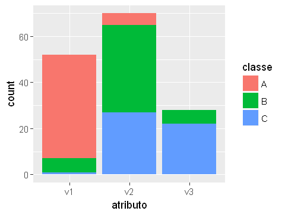

```r
ggplot(data=dt, aes(x=atributo, fill = classe)) + geom_bar()
```

- Ao utilizar o *atributo* para saber o quanto ele permite deixar o conjunto de dados mais organizado, temos a seguinte tabela de frequência

```r
table(dt$atributo, dt$classe)
```

```
      A  B  C
  v1 45  6  1
  v2  5 38 27
  v3  0  6 22
```

- Assim, se $X$ é o conjunto de dados total, utilizando o atributo dividimos o conjunto em $X_1$, $X_2$ e $X_3$.
- Cada um desses conjuntos tem um valor de entropia, que pode ser calculado a função de *entropia*
- Para $v_1$ o conjunto $X_1$ é dado por **dt[atributo == "v1", , ]**

```r
entropia(dt[atributo == "v1"]$classe)
```

0.649609634695663

- Para $v_2$ o conjunto $X_2$ é dado por **dt[atributo == "v2", , ]**

```r
entropia(dt[atributo == "v2"]$classe)
```

1.28052803774916

- Para $v_3$ o conjunto $X_3$ é dado por **dt[atributo == "v3", , ]**

```r
entropia(dt[atributo == "v3"]$classe)
```

0.74959525725948

- Uma vez calculadas as entropias para cada valor do atributo, podemos calcular a **Entropia do Atributo**

\begin{array}{lllll} E(X,A) & = & \sum_{j=1}^{m} \frac{|X_{j}|}{|X|} \times E(X_{j}) \\ E(X,A) & = & \sum_{j=1}^{m=3} \frac{|X_{j}|}{|X|} \times E(X_{j}) \\ E(X,A) & = & \frac{|X_{1}|}{|X|} \times E(X_{1}) + \frac{|X_{2}|}{|X|} \times E(X_{2}) + \frac{|X_{3}|}{|X|} \times E(X_{3}) \\ E(X,A) & = & \frac{52}{150} \times E(X_{1}) + \frac{70}{150} \times E(X_{2}) + \frac{28}{150} \times E(X_{3}) \\ E(X,A) & = & \frac{52}{150} \times 0.65 + \frac{70}{150} \times 1.28 + \frac{28}{150} \times 0.75 \\ E(X,A) & = & 0.23 + 0.60 + 0.14 \\ E(X,A) & = & 0.97 \end{array}

- Esses cálculos inidicam que:
  - O valor do atributo $v_1$ contribuiu com $0.23$ para a entropia,
  - O valor $v_2$ com $0.60$, e
  - O valor $v_3$ com $0.14$.
- O total da entropia ficou em $0.97$
- Mas não devemos esquecer que a entropia inicial do conjunto de dados (50 exemplos de cada classe) foi de $1.58$

```r
entropia(dt$classe)
```

1.58496250072116

- O que indica que utilizando o *atributo* conseguimos organizar melhor o conjunto de dados, pois a *entropia* é diminuiu, e consequentemente, a *desordem* do conjunto de dados.

#### Função para Cálculo da Entropia do Atributo

```r
entropia.atributo <- function(X,A, show.partial.results=F){
    n <- nrow(X)
    Xj <- X[,.(prop = .N/n, entropia = entropia(classe)),by=A]
    if (show.partial.results) print(Xj)
    entropia.atributo <- sum(Xj$prop * Xj$entropia)
    entropia.atributo
}

entropia.atributo( X = dt, A = "atributo", show.partial.results=T)
```

```
   atributo      prop  entropia
1:       v1 0.3466667 0.6496096
2:       v2 0.4666667 1.2805280
3:       v3 0.1866667 0.7495953
```

0.962702205665873

#### Dados de Shelter Animals

```r
dt <- fread (file = "data/train_processed.csv" )
dt$classe <- dt$OutcomeType
```

- Uma vez discretizado o atributo **DaysuponOutcome** usando as três técnicas, armazenados em:
  - **DaysuponOutcome.intervalo_a**
  - **DaysuponOutcome.intervalo_b**
  - **DaysuponOutcome.intervalo_c**
- Qual dessas três técnicas apresenta menor valor de entropia?

```r
entropia.atributo(dt,"DaysuponOutcome.intervalo_a")
```

1.71395576064402

```r
entropia.atributo(dt,"DaysuponOutcome.intervalo_b")
```

1.75704046112564

```r
entropia.atributo(dt,"DaysuponOutcome.intervalo_c")
```

1.56353801471514

- Esses atributos discretizados apresentam entropia melhor do que a entropia inicial dos dados?

```r
entropia(dt$OutcomeType)
```

1.79393910994478

## Medidas de Importância

### Ganho de Informação (*Information Gain*)

- O Ganho de Informação (IG) de um atrbiuto consiste diferença entre a entropia inicial do conjunto de dados $X$ e a entropia ao utilizar o atributo $A$.
- Equação:

$$ IG = E(X) - E(X,A)$$

- O IG quantifica a redução de entropia esperada por conhecer os valores do atributo A no conjunto X.

```r
ganho.de.informacao <- function(X,A){
    entropia(X$classe) - entropia.atributo(X,A)
}
```

#### O problema do Ganho de Informação e da Entropia:

- Ela é enviesada ou tendenciosa (*baised*) com atributos que possuem muitos valores possíveis.
- Por exemplo, um atributo de ID (como o AnimalID no dataset Shelter Animals), que divide o conjunto de dados em 1 exemplo por partição $X_j$.
- Assim, embora tenhamos muitas partições $X_j$, todas as partições apresentam um único exemplo (de uma classe), consequentemente, entropia baixa.
- A soma dessa entropias irão fazer com que $E(X,A) = 0$, o que maximiza o $IG$.
- No entanto, o atributo de identificação não deve ser um bom atributo para predição.

### Taxa de Ganho (*Gain Ratio*)

- A Taxa de Ganho de um atrbiuto consiste na razão entre o ganho de informação e a informação intrínseca do atributo que vai dividir o conjunto de dados.
- A informação intrínseca (*Intrinsic Information* - I) nada mais é do que a entropia do atributo, sem usar informação da classe.
- Equação:

$$ GainRatio(X,A) = \frac{IG(X,A)}{I(A)} = \frac{IG(X,A)}{E(A)}$$

- onde,
  - $IG(X,A)$ é o ganho de informação do atributo $A$ no conjunto $X$
  - $E(A)$ é a entropia (*cuidado*: não é $E(X,A)$ )

#### Implementação da Função

```r
razao.de.ganho <- function(X,A){
    ganho.de.informacao(X,A) / entropia( X[, get(A)] )
}
```

#### Exemplo: Ganho de Informação *vs* Razão de Ganho

- Atributo **AnimalID**

```r
data.table( atributo = "AnimalID",
    ganho.de.informacao = ganho.de.informacao(dt,"AnimalID"),
    razao.de.ganho = razao.de.ganho(dt,"AnimalID" ) )
```

| atributo | ganho.de.informacao | razao.de.ganho |
| --- | --- | --- |
| AnimalID | 1.793939 | 0.1219859 |

- Atributo **SexuponOutcome**

```r
data.table( atributo = "SexuponOutcome",
    ganho.de.informacao = ganho.de.informacao(dt,"SexuponOutcome"),
    razao.de.ganho = razao.de.ganho(dt,"SexuponOutcome" ) )
```

| atributo | ganho.de.informacao | razao.de.ganho |
| --- | --- | --- |
| SexuponOutcome | 0.2986934 | 0.1480287 |